# Exploratory Data Analysis using Music Sales

Practicing data analysis and data science using pandas package for data preparation and plotly package for data visualization. The dataset can be downloaded was originally from Kaggle.

## Data preparation

### Importing packages

```python
import pandas as pd

music_sales = './datasets/music_sales.csv'
df = pd.read_csv(filepath_or_buffer=music_sales, index_col=['index']).drop(columns=['Number of Records'])
df['Value (Actual)'] = df['Value (Actual)'].fillna(value=0).apply(func=lambda x: 0 if x < 0 else x)
df.head()
```

| index | Format | Metric | Year | Value (Actual) |
| --- | --- | --- | --- | --- |
| 0 | CD | Units | 1973 | 0.0 |
| 1 | CD | Units | 1974 | 0.0 |
| 2 | CD | Units | 1975 | 0.0 |
| 3 | CD | Units | 1976 | 0.0 |
| 4 | CD | Units | 1977 | 0.0 |

```python
df.info()
```

```
<class 'pandas.core.frame.DataFrame'>
Index: 3008 entries, 0 to 3007
Data columns (total 4 columns):
 #   Column          Non-Null Count  Dtype
---  ------          --------------  -----
 0   Format          3008 non-null   object
 1   Metric          3008 non-null   object
 2   Year            3008 non-null   int64
 3   Value (Actual)  3008 non-null   float64
dtypes: float64(1), int64(1), object(2)
memory usage: 117.5+ KB
```

## Data Visualization

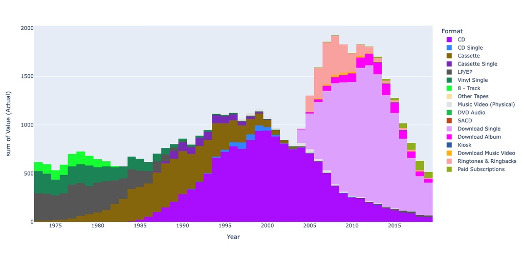

```python
from plotly.express import histogram
from plotly.colors import qualitative

histogram(data_frame=df[df['Metric'] == 'Units'], x='Year', y='Value (Actual)', color='Format',
          color_discrete_sequence=qualitative.Alphabet, height=600, nbins=df['Year'].nunique(), ).show()
```

*The histogram portrays the intricate distribution of music sales by units across diverse years, unveiling a journey through the ever-evolving music industry. The number of music sales units depicted and the passage of years showcased, this masterpiece unveils each bar carrying the essence of the music sales format it represents.*

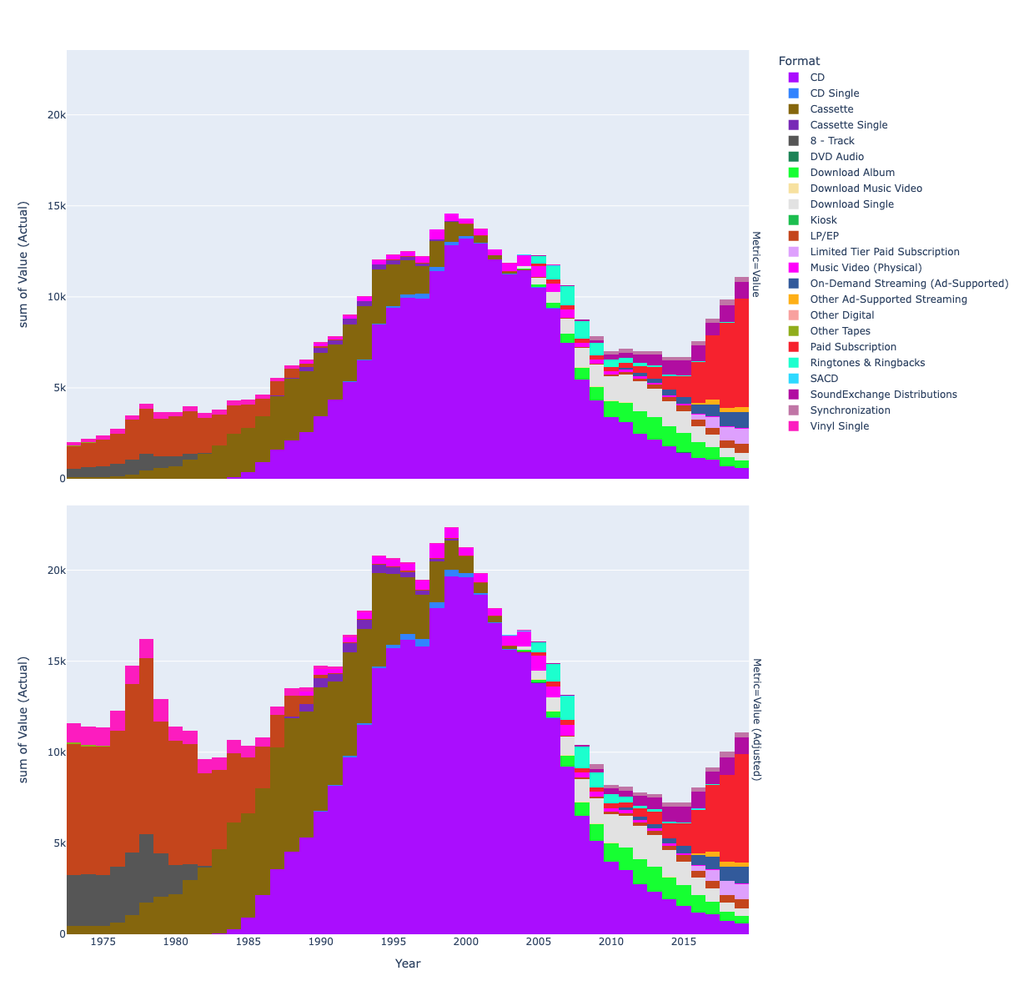

```python
histogram(data_frame=df[df['Metric'] != 'Units'], x='Year', y='Value (Actual)', color='Format', facet_row = 'Metric',
          color_discrete_sequence=qualitative.Alphabet, height=1200, nbins=df['Year'].nunique(), ).show()
```

*Using the histogram above, depicting the distribution of music sales by metric (excluding units) across various years. This represents the value of music sales, and the represents the years. The histogram corresponds to a specific format of music sales, with its color indicating the format. Additionally, the visualization is organized using facetting by metric, allocating each metric its own row in the chart.*

```python
from plotly.express import scatter
for metric in ['Units', 'Value (Adjusted)']:
    scatter(data_frame=df[df['Metric'] == metric].dropna(), x='Year', y='Format', size='Value (Actual)', color='Value (Actual)').show()
```

[output not shown]

## Conclusion

The accompanying data visualization comprises a histogram, a distribution chart, a scatter plot, and various relevant metrics to offer a comprehensive and informative story about the evolving music industry over the years.

The histogram delves into the distribution of music sales by units across diverse years. Through a collection of bars, each representing a specific format of music sales, the histogram provides a nuanced and intricate depiction of the fluctuating landscape of the music industry. The height of each bar symbolizes the number of music sales units, while the passage of years is visually showcased. As a result, this visualization encapsulates the essence of each music sales format it represents, unravelling a captivating journey through the ever-evolving music industry.

In contrast, the distribution chart within the histogram revolves around the distribution of music sales by metric, excluding units, over the course of different years. This particular visualization focuses on the value of music sales in relation to the years under consideration. The distinctive color scheme employed in the chart aids in distinguishing the different formats of music sales. Additionally, for clarity and organization, the visualization adopts facetting by metric, allocating each metric its own row. Thus, the distribution chart presents a comprehensive overview of the changing value of music sales across different formats and years.

In conclusion, this data visualization provides a conclusive and formal representation of the intricate journey of the music industry across diverse years. Delivered through a combination of a histogram, a distribution chart, and a scatter plot, this storytelling effectively captures the distribution, value, and correlation of music sales formats over time.